# performr vignette

Silas Tittes

June 14, 2026

NOTE: This document is in progress. Feel free to suggest changes on the package’s [GitHub page](https://github.com/silastittes/performr), or by email silas.tittes@gmail.com.

# How to use `performr` package

`performr` implements a probabilistic Bayesian hierarchical model (using [Stan](http://mc-stan.org/)) to predict tolerance/performance curves for a set of input taxa. The manuscript that describes the method is in revision. This page is intended to help those interested in using the model for their own data.

## Installation

Installing `performr` is done using the following command:

```r
#install performr
pak::pak("silastittes/performr")

#install cmdstanr and CmdStan (required to compile and run the Stan model)
install.packages("cmdstanr", repos = c("https://stan-dev.r-universe.dev", getOption("repos")))
cmdstanr::install_cmdstan()

#load other libraries used below
library(performr)
library(tidyverse)
library(ggridges)
theme_set(theme_minimal())
```

`performr` now uses [cmdstanr](https://mc-stan.org/cmdstanr/) as its Stan backend. Unlike the previous rstan-based version, the Stan model is compiled on first use rather than at package install time, so the install step above should be fast. The `cmdstanr::install_cmdstan()` call downloads and builds CmdStan — you only need to do this once. Run `cmdstanr::cmdstan_version()` to confirm everything is set up correctly.

`performr` depends on several R packages. These can take some time to install, but usually goes smoothly as long as your R is up to date! If you run into troubles, check the R session info at the bottom of this page.

## Simulating example data

For demonstration and model validation, data can be simulated from the hyperpriors. The true parameter values for both hyper parameters and species-level parameters are returned in addition to a simulated data frame. All arguments have defaults, but fiddling with parameter values is encouraged.

I’ll demonstrate a data set with three species, 20 positions sampled along an environmental axis, and three replicates per species at each position along the axis (wouldn’t that be something):

```r
set.seed(223524)
perf_df <- simulate_data(n_spp = 3, n_axis = 20, n_reps = 3)
```

Here are a few quick ways to look at the output:

```r
head(perf_df$sim_data)
```

```
## # A tibble: 6 × 4
##       x  trait     mu species
##   <dbl>  <dbl>  <dbl>   <int>
## 1 -4.72 0.0668 0.0389       1
## 2 -4.72 0.0471 0.0389       1
## 3 -4.72 0      0.0389       1
## 4 -4.32 0.0560 0.0983       1
## 5 -4.32 0.102  0.0983       1
## 6 -4.32 0.0726 0.0983       1
```

```r
str(perf_df)
```

```
## List of 2
##  $ true_params:List of 12
##   ..$ shape1    : num [1:3] 3.84 3.17 2.25
##   ..$ shape2    : num [1:3] 2.61 2.97 2.64
##   ..$ stretch   : num [1:3] 2.55 2.1 1.97
##   ..$ x_min     : num [1:3] -5.76 -5.39 -4.55
##   ..$ x_max     : num [1:3] 4.41 2.52 4.38
##   ..$ nu        : num [1:3] 17.1 33.6 26
##   ..$ mu_shape1 : num 2.57
##   ..$ mu_shape2 : num 2.91
##   ..$ mu_stretch: num 1.75
##   ..$ mu_min    : num -5.39
##   ..$ mu_max    : num 4.22
##   ..$ mu_nu     : num 3.96
##  $ sim_data   : tibble [180 × 4] (S3: tbl_df/tbl/data.frame)
##   ..$ x      : num [1:180] -4.72 -4.72 -4.72 -4.32 -4.32 ...
##   ..$ trait  : num [1:180] 0.0668 0.0471 0 0.056 0.1024 ...
##   ..$ mu     : num [1:180] 0.0389 0.0389 0.0389 0.0983 0.0983 ...
##   ..$ species: int [1:180] 1 1 1 1 1 1 1 1 1 1 ...
```

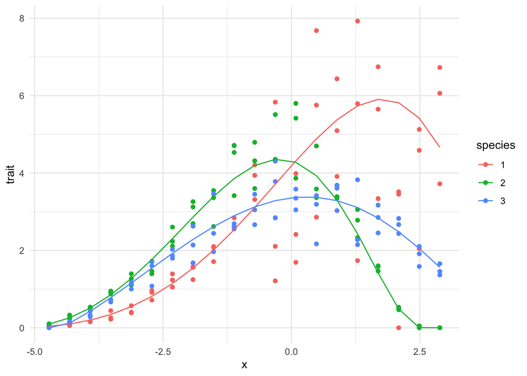

Simulated data for three ‘species’ plotted with the curves used to generate the samples.

```r
perf_df$sim_data %>%
  mutate(species = factor(species)) %>%
  ggplot(aes(x, trait, colour = species)) +
  geom_point() +
  geom_line(aes(x, mu))
```

There are 3 columns of input data required to run the model, where each row represents an individual unit of sampling (name and order the columns as you please):

- Integers representing the groups (or “species”) each sample belongs to – even if there is only one group.
- An x-axis consisting of measurements from some environmental variable (soil moisture, temperature, etc.).
- A measure of performance for each individual studied in that environmental condition (trait). *Rows with missing values must be removed before fitting* – `tidyr::drop_na()` is good for this.

## Fitting the model with `performr::stan_performance()`

Now that we have some example data, we can fit the model. Arguments that include “*pr*” are parameters for the priors (for brevity, I will gloss over prior details here and refer readers to the paper once available), which I’ve set to match the defaults of the simulation (so this is best case scenario for the model getting it right). Notice, I’ve set a seed to make the results reproducible, and I’ve reduced the total number of iterations to 200. The default iterations of 2000 (or more) should be used for analysis, but 200 is good for demonstration and troubleshooting purposes.

```r
perf_out <-
  stan_performance(
    df = perf_df$sim_data,
    response = trait,
    treatment = x,
    group_ids = species,
    shape1_pr_mu = 2,
    shape1_pr_sig = 1,
    shape2_pr_mu = 2,
    shape2_pr_sig = 1,
    stretch_pr_mu = 1,
    stretch_pr_sig = 1,
    nu_pr_shape = 8,
    nu_pr_scale = 3,
    min_pr_mu = -5,
    min_pr_sig = 1,
    max_pr_mu = 5,
    max_pr_sig = 1,
    iter = 200,
    seed = 7345
  )
```

Stan may warn about max tree depth or divergent transitions. You can pass `max_treedepth` (12–14 works well) and `adapt_delta` (default 0.95) directly to `stan_performance()` to address these. The optional `file_id` argument saves the chain CSV files to your working directory if you want to reload results later.

## Output

The output is the same as any Stan model.

```r
knitr::kable(perf_out$summary(), digits = 3)
```

| variable | mean | median | sd | mad | q5 | q95 | rhat | ess_bulk | ess_tail |
| --- | --- | --- | --- | --- | --- | --- | --- | --- | --- |
| lp__ | -14.115 | -13.974 | 3.671 | 3.858 | -20.399 | -8.725 | 1.033 | 179.938 | 173.501 |
| shape1[1] | 3.593 | 3.553 | 0.363 | 0.342 | 3.053 | 4.224 | 1.020 | 322.327 | 171.916 |
| shape1[2] | 3.329 | 3.315 | 0.197 | 0.198 | 3.026 | 3.689 | 1.006 | 500.888 | 297.427 |
| shape1[3] | 2.438 | 2.435 | 0.092 | 0.090 | 2.297 | 2.604 | 1.006 | 309.818 | 275.726 |
| shape2[1] | 3.201 | 3.057 | 0.789 | 0.750 | 2.197 | 4.561 | 1.073 | 57.741 | 32.852 |
| shape2[2] | 3.085 | 3.108 | 0.303 | 0.321 | 2.594 | 3.558 | 1.008 | 364.156 | 234.587 |
| shape2[3] | 3.344 | 3.285 | 0.566 | 0.572 | 2.584 | 4.329 | 1.016 | 239.383 | 168.038 |
| stretch[1] | 2.548 | 2.553 | 0.206 | 0.216 | 2.244 | 2.866 | 1.021 | 155.902 | 245.103 |
| stretch[2] | 2.138 | 2.141 | 0.070 | 0.066 | 2.025 | 2.254 | 1.019 | 364.350 | 275.915 |
| stretch[3] | 1.823 | 1.818 | 0.095 | 0.091 | 1.665 | 1.975 | 1.003 | 305.407 | 241.361 |
| min_max[1,1] | -5.368 | -5.330 | 0.390 | 0.364 | -5.990 | -4.813 | 1.022 | 347.443 | 214.894 |
| min_max[2,1] | -5.523 | -5.501 | 0.180 | 0.180 | -5.852 | -5.273 | 1.004 | 533.458 | 356.949 |
| min_max[3,1] | -4.679 | -4.671 | 0.083 | 0.082 | -4.825 | -4.553 | 1.005 | 375.772 | 282.052 |
| min_max[1,2] | 5.013 | 4.977 | 0.675 | 0.671 | 4.011 | 6.124 | 1.046 | 96.257 | 125.304 |
| min_max[2,2] | 2.546 | 2.565 | 0.099 | 0.098 | 2.381 | 2.684 | 1.010 | 270.672 | 249.998 |
| min_max[3,2] | 4.846 | 4.820 | 0.519 | 0.518 | 4.032 | 5.706 | 1.014 | 234.324 | 242.541 |
| nu[1] | 18.249 | 18.169 | 1.854 | 1.702 | 15.088 | 21.416 | 1.016 | 528.802 | 339.784 |
| nu[2] | 38.531 | 38.591 | 3.704 | 3.788 | 32.601 | 44.525 | 1.005 | 370.027 | 243.143 |
| nu[3] | 32.698 | 32.671 | 3.111 | 2.913 | 27.295 | 37.828 | 1.011 | 659.827 | 262.034 |
| mu_shape1 | 2.822 | 2.845 | 0.520 | 0.504 | 1.978 | 3.642 | 1.010 | 400.262 | 261.553 |
| mu_shape2 | 2.906 | 2.906 | 0.571 | 0.615 | 2.048 | 3.797 | 1.009 | 267.482 | 288.215 |
| mu_stretch | 1.891 | 1.881 | 0.561 | 0.655 | 0.972 | 2.818 | 1.000 | 331.372 | 248.440 |
| mu_min | -5.121 | -5.114 | 0.550 | 0.553 | -6.036 | -4.239 | 1.022 | 266.354 | 280.657 |
| mu_max | 4.316 | 4.333 | 0.585 | 0.584 | 3.342 | 5.272 | 1.010 | 216.434 | 185.929 |
| mu_nu | 0.291 | 0.288 | 0.057 | 0.058 | 0.202 | 0.388 | 1.039 | 654.503 | 347.760 |
| x_min[1] | -5.368 | -5.330 | 0.390 | 0.364 | -5.990 | -4.813 | 1.022 | 347.443 | 214.894 |
| x_min[2] | -5.523 | -5.501 | 0.180 | 0.180 | -5.852 | -5.273 | 1.004 | 533.458 | 356.949 |
| x_min[3] | -4.679 | -4.671 | 0.083 | 0.082 | -4.825 | -4.553 | 1.005 | 375.772 | 282.052 |
| x_max[1] | 5.013 | 4.977 | 0.675 | 0.671 | 4.011 | 6.124 | 1.046 | 96.257 | 125.304 |
| x_max[2] | 2.546 | 2.565 | 0.099 | 0.098 | 2.381 | 2.684 | 1.010 | 270.672 | 249.998 |
| x_max[3] | 4.846 | 4.820 | 0.519 | 0.518 | 4.032 | 5.706 | 1.014 | 234.324 | 242.541 |

We can access the number of posterior draws directly from the model object.

```r
ndraws <- posterior::ndraws(perf_out$draws())
```

There are a lot of good packages out there for visualizing posteriors. I haven’t learned any of them yet, but here’s a quick approach I’m fond of:

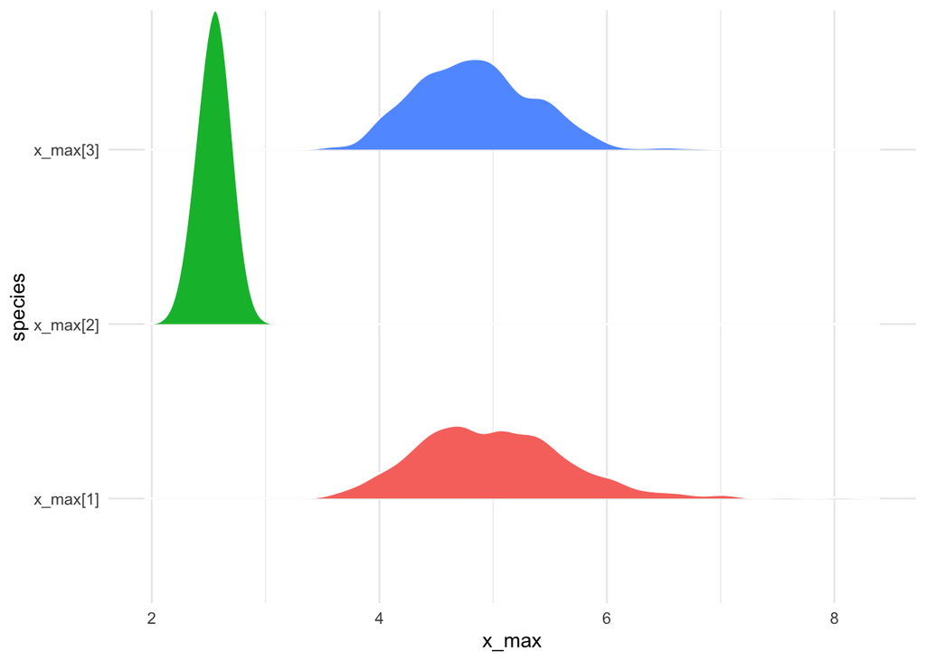

```r
#choose parameter
param <- "x_max"

max_df <- perf_out$draws(variables = param) %>%
  posterior::as_draws_df() %>%
  select(-.chain, -.iteration, -.draw) %>%
  gather(species, value)
max_df %>%
  ggplot(aes(value, species,  fill = species)) +
  geom_density_ridges(colour = "white") +
  xlab(param) +
  theme(legend.position = "none")
```

Quickly, let’s eyeball how these marginal posteriors for the x_max parameter (where performance falls to zero above the optimum) for each species.

```r
max_df %>%
  group_by(species) %>%
  summarise(
    cred_025 = quantile(value, 0.025),
    cred_975 = quantile(value, 0.975)
  ) %>%
  mutate(
    truth = perf_df$true_params$x_max
  ) %>%
  mutate(
    within_cred = truth > cred_025 & truth < cred_975
  )
```

```
## # A tibble: 3 × 5
##   species  cred_025 cred_975 truth within_cred
##   <chr>       <dbl>    <dbl> <dbl> <lgl>
## 1 x_max[1]     3.91     6.52  4.41 TRUE
## 2 x_max[2]     2.35     2.73  2.52 TRUE
## 3 x_max[3]     3.96     5.85  4.38 TRUE
```

Cool, looks like the 95% credible interval captures the true value in each case. It would be easy to extend this approach using a function and quickly verify each parameter. Notice the increased uncertainty in posteriors further from the treatments on the x-axis … Love that!

## Visualize uncertainty in curves predictions

First, let’s generate a tidy data frame with all the parameters, plus some valuable derived parameters, like the optimum, area, and breadth for each species. We will use this data frame for other tasks below as well.

```r
head(
  tidy_perf <-
    perform_df(
      perf_out,
      species_order = c(1, 2, 3)
    )
)
```

```
## # A tibble: 6 × 12
## # Groups:   species [1]
##   species x_min  draw x_max shape1 shape2 stretch    nu maxima breadth  area
##   <chr>   <dbl> <int> <dbl>  <dbl>  <dbl>   <dbl> <dbl>  <dbl>   <dbl> <dbl>
## 1 1       -5.30     1  5.76   3.61   4.34    2.35  17.5   1.55   11.1   26.0
## 2 1       -5.99     2  4.97   4.12   3.59    2.37  18.7   1.65   11.0   26.0
## 3 1       -6.50     3  4.41   4.49   3.03    2.38  19.3   1.70   10.9   26.0
## 4 1       -5.12     4  4.32   3.39   2.48    2.62  17.9   1.64    9.43  24.7
## 5 1       -5.23     5  4.07   3.63   2.46    2.77  19.3   1.64    9.30  25.8
## 6 1       -5.24     6  5.20   3.41   2.93    2.65  17.3   1.86   10.4   27.7
## # ℹ 1 more variable: special <dbl>
```

The next step is to generate prediction intervals using the `predict_interval()` function. The function generates posterior quantiles for each set of posterior draws specified (`x_draws`), and averages over the quantiles. The argument `p` can takes a vector of credible levels, which can be modified to consider other and/or additional levels.

```r
#set up sequence over the observed data range
x_seq <- seq(min(perf_df$sim_data$x),
             max(perf_df$sim_data$x),
             length.out = 100)

#sub-sample draws randomly
poly_draws <- sample(1:ndraws, 100)

creds <-
  predict_interval(
    x = x_seq,
    par_df = tidy_perf,
    x_draws = poly_draws,
    p = c(0.95, 0.5))

creds %>% group_by(species, level) %>% slice_head(n = 1)
```

```
## # A tibble: 6 × 6
## # Groups:   species, level [6]
##   species     x     lower  upper      mu level
##   <chr>   <dbl>     <dbl>  <dbl>   <dbl> <dbl>
## 1 1       -4.72 0.000850  0.0614 0.0231     50
## 2 1       -4.72 0         0.135  0.0231     95
## 3 2       -4.72 0.0780    0.121  0.0993     50
## 4 2       -4.72 0.0374    0.161  0.0993     95
## 5 3       -4.72 0.0000340 0.0236 0.00246    50
## 6 3       -4.72 0         0.0638 0.00246    95
```

Notice the output of `predict_interval()` also produces a “mu” column, which contains the mean preduction of the curve for each input species.

Here is an example of how the data could be plotted. Other approach using `plot()` are certainly possible:

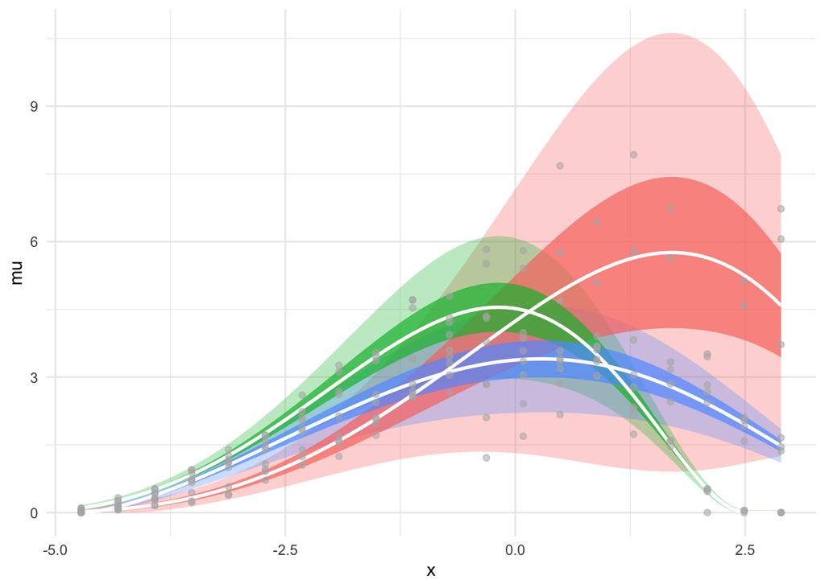

```r
ggplot(data = filter(creds, level == 95)) +
  geom_ribbon(
    aes(x = x,
        ymin = upper,
        ymax = lower,
        fill = species),
    alpha = 0.3,
    inherit.aes = F) +
  geom_ribbon(
    data = filter(creds, level == 50),
    aes(x = x,
        ymin = upper,
        ymax = lower,
        fill = species),
    inherit.aes = F,
    alpha = 0.7) +
  geom_line(aes(x, mu, group = species), inherit.aes = F, colour = "white", lwd = 1) +
  geom_point(
    data = perf_df$sim_data,
    aes(x,
        trait,
        alpha = 0.5),
    inherit.aes = F,
    colour = "grey70") +
  theme(legend.position = "none")
```

## Posterior predictive data generation

Now we can generate pseudo observed data from the posterior draws.

```r
tidy_perf %>%
  filter(draw == 1) %>%
  posterior_predict(par_df = .) %>%
  head()
```

```
## # A tibble: 6 × 5
##       x  trait           mu species  draw
##   <dbl>  <dbl>        <dbl> <chr>   <int>
## 1 -5.41 0      0            1           1
## 2 -5.29 0      0.0000000272 1           1
## 3 -5.18 0      0.000267     1           1
## 4 -5.06 0.0645 0.00157      1           1
## 5 -4.95 0      0.00445      1           1
## 6 -4.83 0      0.00937      1           1
```

By default, the x-axis will be constructed as a sequence of 100 values that start from the minimum posterior draw value of x_min and end at the maximum of x_max. This default can be changed using the x argument. Filtering for posterior draws is not required before using the function – posterior predictive data will be produced for every posterior draw passed to `par_df`.

If you have questions, comments, or concerns, please get in touch. I would be excited to discuss!

[session information not shown]